# HW 2

Jeff Gould

9/8/2020

#### 1 - Read Chapter 3

#### 2 - You are given a set of $m$ objects that is divided into $K$ groups, where the $i^{th}$ group is of size $m_i$. If the goal is to obtain a sample of size $n \le m$, what is the difference between the following sampling schemes?

- We randomly select $n \times m_i/m$ elements from each group
- We randomly select $n$ elements from the data set, without regards for the group to which an object belongs

Consider this simple example: $K = 10$, $m = 100$, $m_i = 10 \,\,\, \forall i \in [1,2,\dots,10]$, $n = 30$

If we randomly select $n \times m_i/m$ elements from each group, then we will look at each group and sample exactly $3$ objects from each group ($n \times m_i/m = 30 *10/100 = 3$). In a more general sense, our sample will have a representation of each group proportional to that groups representation of the entire data set.

If we randomly select $n = 30$ elements out of the entire data set, then there will likely not be representation for each group directly proportional to their represnetation of the whole data set. Using the example above, we could select $6$ elements from group 1, but not even select a single element from group 3, so long as we sampled 30 total elements.

#### 3 - Experiment with different types of binning on the glass data (installed with WEKA or available in R via the mlbench package). Try equal width and equal depth binning. Try various numbers of bins (at least three). Use OneR on the original data and on your binned data. Compare the results and write a brief description of what you observe.

First - test `OneR` on the raw data:

```r
#install.packages("mlbench")
library(mlbench)
library(OneR)
data(Glass)

OneR(Glass)
```

```
##
## Call:
## OneR.data.frame(x = Glass)
##
## Rules:
## If Al = (0.287,0.932] then Type = 1
## If Al = (0.932,1.57]  then Type = 1
## If Al = (1.57,2.22]   then Type = 2
## If Al = (2.22,2.86]   then Type = 7
## If Al = (2.86,3.5]    then Type = 5
##
## Accuracy:
## 100 of 214 instances classified correctly (46.73%)
```

Now bin the data into bins of equal widths, calculate `OneR` for bins of 3, 5, 7, 9, 11, and show an example plot for 5 bins:

```r
equalWidthOneR <- function(bins){

  glassBinEqualWidth <- data.frame(apply(Glass[,1:9], 2, cut, include.lowest = T, breaks = bins))
  glassBinEqualWidth$Type = Glass$Type
  paste0(glue::glue("OneR Results using {bins} bins of equal width: "))
  return(OneR(glassBinEqualWidth))
}
for (i in c(3,5,7,9, 11)) {
  output <- equalWidthOneR(i)
  print(output)
}
```

```
##
## Call:
## OneR.data.frame(x = glassBinEqualWidth)
##
## Rules:
## If Al = (1.36,2.43]  then Type = 2
## If Al = (2.43,3.5]   then Type = 7
## If Al = [0.287,1.36] then Type = 1
##
## Accuracy:
## 113 of 214 instances classified correctly (52.8%)
##
##
## Call:
## OneR.data.frame(x = glassBinEqualWidth)
##
## Rules:
## If Al = (0.932,1.57]  then Type = 1
## If Al = (1.57,2.22]   then Type = 2
## If Al = (2.22,2.86]   then Type = 7
## If Al = (2.86,3.5]    then Type = 5
## If Al = [0.287,0.932] then Type = 1
##
## Accuracy:
## 101 of 214 instances classified correctly (47.2%)
##
##
## Call:
## OneR.data.frame(x = glassBinEqualWidth)
##
## Rules:
## If Mg = (0.641,1.28]     then Type = 2
## If Mg = (1.28,1.92]      then Type = 5
## If Mg = (1.92,2.57]      then Type = 6
## If Mg = (2.57,3.21]      then Type = 2
## If Mg = (3.21,3.85]      then Type = 1
## If Mg = (3.85,4.49]      then Type = 2
## If Mg = [-0.00449,0.641] then Type = 7
##
## Accuracy:
```

[output cut: 24 more lines]

```
## Rules:
## If Al = (0.582,0.874] then Type = 1
## If Al = (0.874,1.17]  then Type = 1
## If Al = (1.17,1.46]   then Type = 1
## If Al = (1.46,1.75]   then Type = 2
## If Al = (1.75,2.04]   then Type = 7
## If Al = (2.04,2.33]   then Type = 7
## If Al = (2.33,2.62]   then Type = 7
## If Al = (2.62,2.92]   then Type = 7
## If Al = (2.92,3.21]   then Type = 5
## If Al = (3.21,3.5]    then Type = 5
## If Al = [0.287,0.582] then Type = 1
##
## Accuracy:
## 124 of 214 instances classified correctly (57.94%)
```

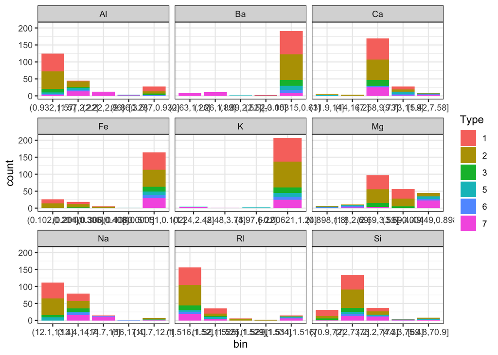

```r
glassBins5EqualWidth <- data.frame(apply(Glass[,1:9], 2, cut, include.lowest = T, breaks = 5))
glassBins5EqualWidth$Type = Glass$Type
glassBins5EqualWidth <- glassBins5EqualWidth %>%
  pivot_longer(cols = RI:Fe, names_to = "element", values_to = "bin")

ggplot(glassBins5EqualWidth, aes(x = bin, fill = Type)) +
  geom_bar() +
  facet_wrap(vars(element), scales = "free_x") +
  theme_bw()
```

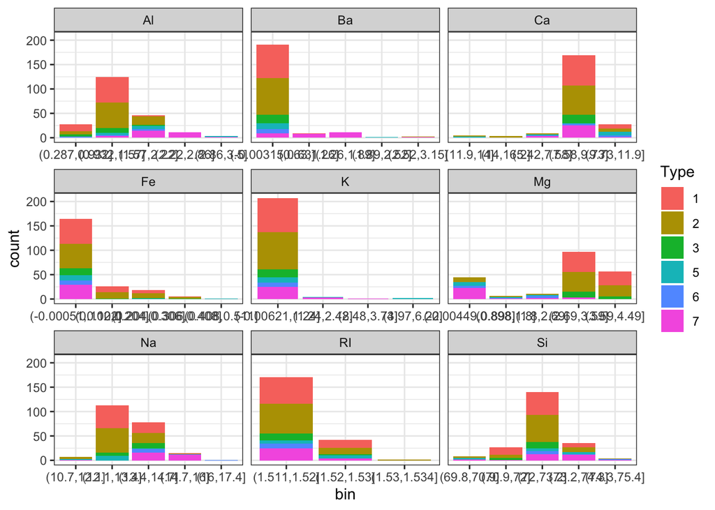

```r
glassBins5EqualWidth <- data.frame(apply(Glass[,1:9], 2, function(x){
    bin(x, method = "length")
  }))
glassBins5EqualWidth$Type = Glass$Type
glassBins5EqualWidth <- glassBins5EqualWidth %>%
  pivot_longer(cols = RI:Fe, names_to = "element", values_to = "bin")

ggplot(glassBins5EqualWidth, aes(x = bin, fill = Type)) +
  geom_bar() +
  facet_wrap(vars(element), scales = "free_x") +
  theme_bw()
```

Now bin the data into bins of equal depth, calculate the `OneR` rule for bins of 3, 5, 7, 9, 11, 13. Additionally, show an example plot for 5 bins.

```r
equalDepthOneR <- function(bins){

  glassBinEqualDepth <- data.frame(apply(Glass[,1:9], 2, function(x){
    cut(x,include.lowest = T,breaks = unique(quantile(x, probs = 0:bins/bins)))
  }
    )
    )
  glassBinEqualDepth$Type = Glass$Type
  print(glue::glue("OneR Results using {bins} bins of equal width: "))
  return(OneR(glassBinEqualDepth))
}
for (i in c(3,5,7,9,11, 13)) {
  output <- equalDepthOneR(i)
  print(output)
}
```

```
## OneR Results using 3 bins of equal width:
##
## Call:
## OneR.data.frame(x = glassBinEqualDepth)
##
## Rules:
## If RI = (1.517,1.518] then Type = 1
## If RI = (1.518,1.534] then Type = 1
## If RI = [1.511,1.517] then Type = 2
##
## Accuracy:
## 98 of 214 instances classified correctly (45.79%)
##
## OneR Results using 5 bins of equal width:
##
## Call:
## OneR.data.frame(x = glassBinEqualDepth)
##
## Rules:
## If Al = (1.15,1.29] then Type = 1
## If Al = (1.29,1.49] then Type = 2
## If Al = (1.49,1.75] then Type = 2
## If Al = (1.75,3.5]  then Type = 7
## If Al = [0.29,1.15] then Type = 1
##
## Accuracy:
## 117 of 214 instances classified correctly (54.67%)
##
## OneR Results using 7 bins of equal width:
##
## Call:
## OneR.data.frame(x = glassBinEqualDepth)
##
## Rules:
## If Al = (1.05,1.22] then Type = 1
## If Al = (1.22,1.31] then Type = 1
## If Al = (1.31,1.45] then Type = 1
## If Al = (1.45,1.57] then Type = 2
## If Al = (1.57,1.88] then Type = 2
## If Al = (1.88,3.5]  then Type = 7
```

[output cut: 52 more lines]

```
## If Al = (1.08,1.18]  then Type = 1
## If Al = (1.18,1.23]  then Type = 1
## If Al = (1.23,1.29]  then Type = 2
## If Al = (1.29,1.34]  then Type = 1
## If Al = (1.34,1.42]  then Type = 1
## If Al = (1.42,1.51]  then Type = 2
## If Al = (1.51,1.56]  then Type = 2
## If Al = (1.56,1.66]  then Type = 2
## If Al = (1.66,1.86]  then Type = 2
## If Al = (1.86,2.15]  then Type = 7
## If Al = (2.15,3.5]   then Type = 7
## If Al = [0.29,0.784] then Type = 1
##
## Accuracy:
## 126 of 214 instances classified correctly (58.88%)
```

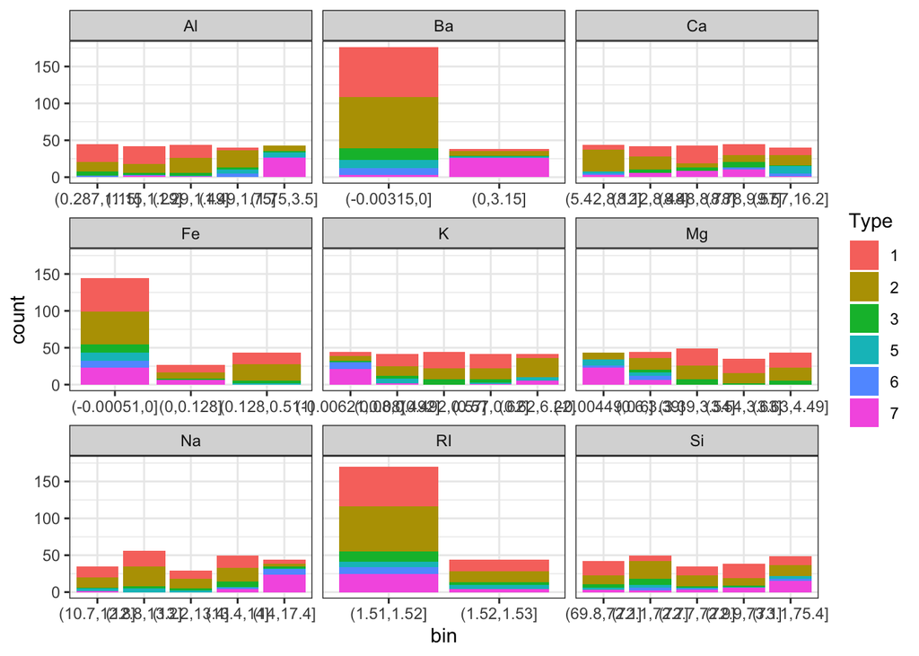

```r
glassBins5EqualDepth <- data.frame(apply(Glass[,1:9], 2, function(x){
    bin(x, method = "content")
  }))
glassBins5EqualDepth$Type = Glass$Type
glassBins5EqualDepth <- glassBins5EqualDepth %>%
  pivot_longer(cols = RI:Fe, names_to = "element", values_to = "bin")

ggplot(glassBins5EqualDepth, aes(x = bin, fill = Type)) +
  geom_bar() +
  facet_wrap(vars(element), scales = "free_x") +
  theme_bw()
```